# Data_story: What did lyrics tell us?

Ting Cai

2019/9/15

### Load all the required libraries

### Load the lyrics data and artist data and combine them

```
## # A tibble: 6 x 11
##   song   year artist genre lyrics    id stemmedwords intro formed members
##   <chr> <dbl> <chr>  <chr> <chr>  <int> <chr>        <fct>  <int> <fct>
## 1 quic…  2009 a-flo… Pop   "I'm …   256 walk quicks… "\n …   1980 "\n   …
## 2 wish…  2007 a-flo… Pop   "It's…   257 smile hair … "\n …   1980 "\n   …
## 3 whol…  2007 a-flo… Pop   "(M. …   258 score score… "\n …   1980 "\n   …
## 4 you-…  2007 a-flo… Pop   "I'd …   259 id id id wr… "\n …   1980 "\n   …
## 5 you-…  2007 a-flo… Pop   "What…   260 whats youre… "\n …   1980 "\n   …
## 6 hot-…  2007 a-flo… Pop   "I'm …   261 hot tonight… "\n …   1980 "\n   …
## # … with 1 more variable: origin <fct>
```

### General overview for key words using word cloud

[interactive chart not shown]

The general word cloud tells us that the most frequent words in lyrics are ‘love’and ’time’.

### Does the word “love” appear so many times for every genre?

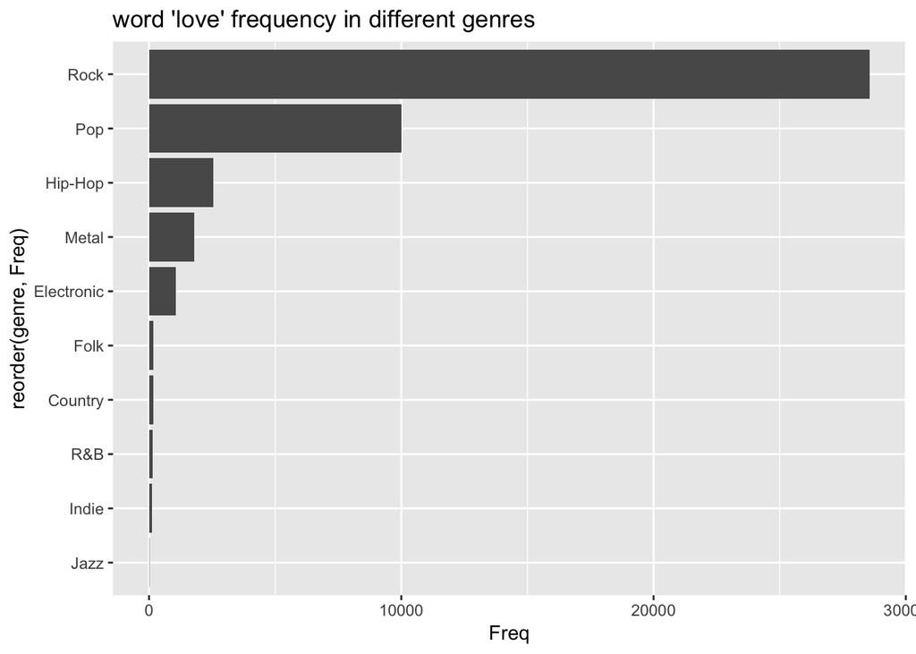

It seems the word “love” appeared most popular in lyrics for Rock and Pop and almost not appear at all in Jazz. But we still did not know if this is the because the artist seldom use “love” in Jazz lyrics or the proportion of Jazz song in this dataset was small. In order to explore deeper, we can plot counts for total words for each genre.

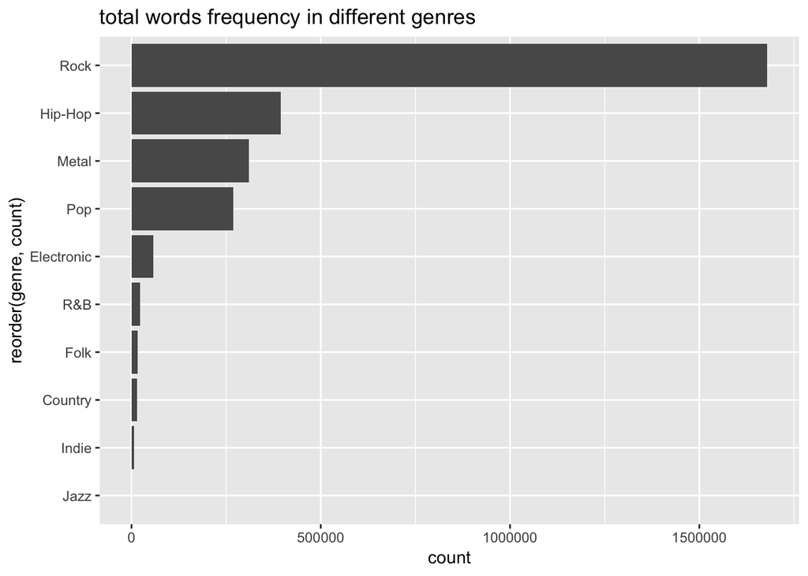

Combine the two plots above, we can conclude that Pop use relatively more “love” in lyrics and R&B use relatively less “love” in lyrics.

### Is there a big difference of topics in lyrics between the 20th century and 21th century?

[interactive chart not shown]

From the two wordclouds, we can see “love” is always the popular topic that was mentioned most frequent in lyrics for both 20th century and 21th century. The word “time” seems mentioned more frequent in 21th century which might mean people focus more on time recent years.

### Sentiment Analysis

```
## # A tibble: 6 x 13
##   song   year artist genre lyrics    id intro formed members origin count
##   <chr> <dbl> <chr>  <chr> <chr>  <int> <fct>  <int> <fct>   <fct>  <int>
## 1 quic…  2009 a-flo… Pop   "I'm …   256 "\n …   1980 "\n   … Liver…    23
## 2 quic…  2009 a-flo… Pop   "I'm …   256 "\n …   1980 "\n   … Liver…    23
## 3 wish…  2007 a-flo… Pop   "It's…   257 "\n …   1980 "\n   … Liver…    27
## 4 wish…  2007 a-flo… Pop   "It's…   257 "\n …   1980 "\n   … Liver…    27
## 5 wish…  2007 a-flo… Pop   "It's…   257 "\n …   1980 "\n   … Liver…    27
## 6 wish…  2007 a-flo… Pop   "It's…   257 "\n …   1980 "\n   … Liver…    27
## # … with 2 more variables: word <chr>, value <dbl>
```

### Visualization of sentiment score against genre.

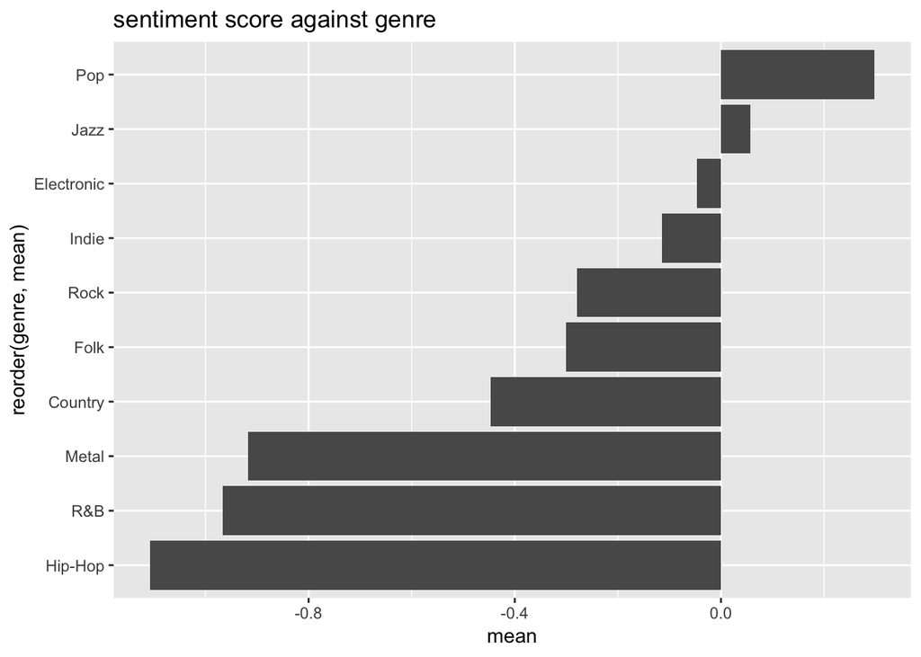

From this bar plot, we can see the genre Pop has a relatively high sentiment score which means the words in Pop lyrics has relatively positive sentiment while the genre Hip-Hop has a relatively low sentiment score which means the words in Hip-Hop lyrics has relatively negative sentiment. In order to prove this, we can take a look at the wordcloud for this two genres.

[interactive chart not shown]

It is obvious that besides some common terms like “love” and “time”, for Pop lyrics, words representing positive sentiment such as “life”, “heart”, “dream” and “baby” appear most frequently while for Hip-Hop lyrics, words representing negative sentiment such as “shit”, “niggas”, “bitch” and “ass” appear most frequently